# About The Dataset:

- The dataset has the numbers of different kinds of teeth (for both top and bottom jaws) for a variety of mammals.
- There is no target/label/dependent column in this dataset to make any prediction.
- Hence, will apply custering on this dataset, describing the data based on similarities between them.
- Applied KMeans and Hierarchical alogorithms

# Dental Anatomy Of Mammals: Basic information before digging into the data

- Mammals have teeth of different sizes and shapes.
- Different teeth are present in mammals not just for eating but for different tasks like defense from other animal.
- These specialized teeth include: Incisors, Canines, Premolars, Molars
- Due to biological evaluation with time some mammals may have all these kind of teeth present but not using all of these now.
- And some might have lost any specific kind of teeth due to lack of usability of that particular teeth.
- So based on such similarity mmamals can be grouped together.

```python
import pandas as pd
import matplotlib.pyplot as plt
import seaborn as sns
import numpy as np
#Import KMeans
from sklearn.cluster import KMeans
```

```python
df = pd.read_csv(r'C:\Users\91842\Downloads\teeth.csv')
df.head()
```

|  | mammal | Right Top Incisors | Right Bottom Incisors | Right Top Canines | Right Bottom Canines | Right Top Premolars | Right Bottom Premolars | Right Top Molars | Right Bottom Molars |
| --- | --- | --- | --- | --- | --- | --- | --- | --- | --- |
| 0 | Brown Bat | 2 | 3 | 1 | 1 | 3 | 3 | 3 | 3 |
| 1 | Mole | 3 | 2 | 1 | 0 | 3 | 3 | 3 | 3 |
| 2 | Silver Hair Bat | 2 | 3 | 1 | 1 | 2 | 3 | 3 | 3 |
| 3 | Pigmy Bat | 2 | 3 | 1 | 1 | 2 | 2 | 3 | 3 |
| 4 | Mouse Bat | 2 | 3 | 1 | 1 | 1 | 2 | 3 | 3 |

```python
df.columns.tolist()
```

```
['mammal',
 'Right Top Incisors',
 'Right Bottom Incisors',
 'Right Top Canines',
 'Right Bottom Canines',
 'Right Top Premolars',
 'Right Bottom Premolars',
 'Right Top Molars',
 'Right Bottom Molars']
```

```python
from sklearn.preprocessing import StandardScaler
scaler = StandardScaler()
scaled_data = scaler.fit_transform(df[['Right Top Incisors',
 'Right Bottom Incisors',
 'Right Top Canines',
 'Right Bottom Canines',
 'Right Top Premolars',
 'Right Bottom Premolars',
 'Right Top Molars',
 'Right Bottom Molars']])
```

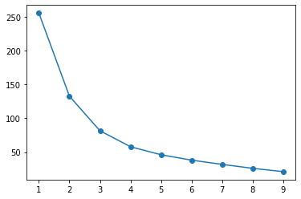

```python
#elbow plot
cluster_range = range(1,10)
cluster_error = []

for num_cluster in cluster_range:
    clusters = KMeans(num_cluster)
    clusters.fit(scaled_data)
    cluster_error.append(clusters.inertia_)

plt.plot(cluster_range,cluster_error,marker='o')
```

- From Elbow graph either we can take K as 3 or can take as 4
- Considering K as 3 at first.

```python
#create the instance of the KMeans with optimum no of clusters=3
clusters = KMeans(n_clusters=3)

#fit the scaled data to the model
clusters.fit(scaled_data)

#clusters to which each point has been allocated
clusters.labels_
```

```
array([2, 2, 2, 2, 2, 2, 1, 1, 1, 1, 1, 1, 1, 0, 0, 0, 0, 0, 0, 0, 0, 0,
       0, 0, 0, 0, 0, 0, 2, 2, 2, 2])
```

```python
#store the clusters to the original data
df['cluster_id'] = clusters.labels_
df.head()
```

[output not shown]

#### Cluster Identification:

```python
cluster_0 = df[df['cluster_id'] == 0]
cluster_1 = df[df['cluster_id'] == 1]
cluster_2 = df[df['cluster_id'] == 2]
```

#### Check who belongs to which cluster:

```python
df[df['cluster_id'] == 0]
```

[output not shown]

- So, Wolf, Bear, Jaguar belong to the same cluster , i.e Cluster0

```python
df[df['cluster_id'] == 1]
```

|  | mammal | Right Top Incisors | Right Bottom Incisors | Right Top Canines | Right Bottom Canines | Right Top Premolars | Right Bottom Premolars | Right Top Molars | Right Bottom Molars | cluster_id |
| --- | --- | --- | --- | --- | --- | --- | --- | --- | --- | --- |
| 6 | Pika | 2 | 1 | 0 | 0 | 2 | 2 | 3 | 3 | 1 |
| 7 | Rabbit | 2 | 1 | 0 | 0 | 3 | 2 | 3 | 3 | 1 |
| 8 | Beaver | 1 | 1 | 0 | 0 | 2 | 1 | 3 | 3 | 1 |
| 9 | Groundhog | 1 | 1 | 0 | 0 | 2 | 1 | 3 | 3 | 1 |
| 10 | Gray Squirrel | 1 | 1 | 0 | 0 | 1 | 1 | 3 | 3 | 1 |
| 11 | House Mouse | 1 | 1 | 0 | 0 | 0 | 0 | 3 | 3 | 1 |
| 12 | Porcupine | 1 | 1 | 0 | 0 | 1 | 1 | 3 | 3 | 1 |

- So Squirrel, Mouse and Porcupine belongs to the same cluster , i.e Cluster1.

```python
df[df['cluster_id'] == 2]
```

[output not shown]

- So different types of bats and Mole etc belong to the same cluster , i.e Cluster2.

#### Cluster summary:

```python
cluster_0.describe()
```

|  | Right Top Incisors | Right Bottom Incisors | Right Top Canines | Right Bottom Canines | Right Top Premolars | Right Bottom Premolars | Right Top Molars | Right Bottom Molars | cluster_id |
| --- | --- | --- | --- | --- | --- | --- | --- | --- | --- |
| count | 15.000000 | 15.000000 | 15.0 | 15.0 | 15.000000 | 15.000000 | 15.000000 | 15.000000 | 15.0 |
| mean | 2.933333 | 2.600000 | 1.0 | 1.0 | 3.600000 | 3.400000 | 1.333333 | 1.800000 | 0.0 |
| std | 0.258199 | 0.632456 | 0.0 | 0.0 | 0.507093 | 0.736788 | 0.617213 | 0.676123 | 0.0 |
| min | 2.000000 | 1.000000 | 1.0 | 1.0 | 3.000000 | 2.000000 | 1.000000 | 1.000000 | 0.0 |
| 25% | 3.000000 | 2.000000 | 1.0 | 1.0 | 3.000000 | 3.000000 | 1.000000 | 1.000000 | 0.0 |
| 50% | 3.000000 | 3.000000 | 1.0 | 1.0 | 4.000000 | 4.000000 | 1.000000 | 2.000000 | 0.0 |
| 75% | 3.000000 | 3.000000 | 1.0 | 1.0 | 4.000000 | 4.000000 | 1.500000 | 2.000000 | 0.0 |
| max | 3.000000 | 3.000000 | 1.0 | 1.0 | 4.000000 | 4.000000 | 3.000000 | 3.000000 | 0.0 |

```python
cluster_1.describe()
```

|  | Right Top Incisors | Right Bottom Incisors | Right Top Canines | Right Bottom Canines | Right Top Premolars | Right Bottom Premolars | Right Top Molars | Right Bottom Molars | cluster_id |
| --- | --- | --- | --- | --- | --- | --- | --- | --- | --- |
| count | 7.000000 | 7.0 | 7.0 | 7.0 | 7.000000 | 7.000000 | 7.0 | 7.0 | 7.0 |
| mean | 1.285714 | 1.0 | 0.0 | 0.0 | 1.571429 | 1.142857 | 3.0 | 3.0 | 1.0 |
| std | 0.487950 | 0.0 | 0.0 | 0.0 | 0.975900 | 0.690066 | 0.0 | 0.0 | 0.0 |
| min | 1.000000 | 1.0 | 0.0 | 0.0 | 0.000000 | 0.000000 | 3.0 | 3.0 | 1.0 |
| 25% | 1.000000 | 1.0 | 0.0 | 0.0 | 1.000000 | 1.000000 | 3.0 | 3.0 | 1.0 |
| 50% | 1.000000 | 1.0 | 0.0 | 0.0 | 2.000000 | 1.000000 | 3.0 | 3.0 | 1.0 |
| 75% | 1.500000 | 1.0 | 0.0 | 0.0 | 2.000000 | 1.500000 | 3.0 | 3.0 | 1.0 |
| max | 2.000000 | 1.0 | 0.0 | 0.0 | 3.000000 | 2.000000 | 3.0 | 3.0 | 1.0 |

```python
cluster_2.describe()
```

[output not shown]

[figure not shown]

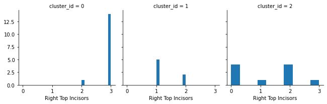

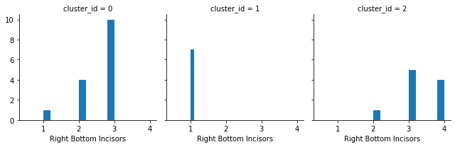

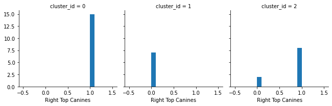

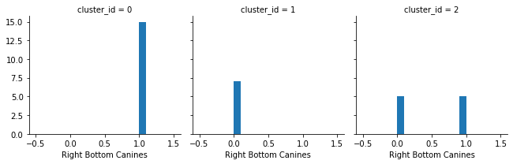

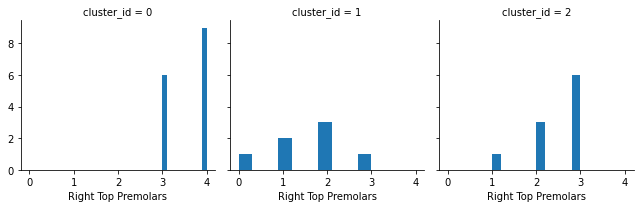

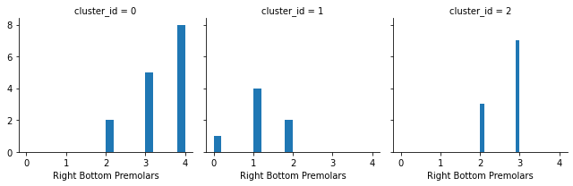

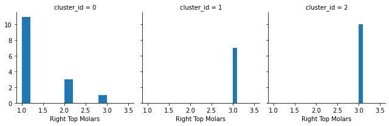

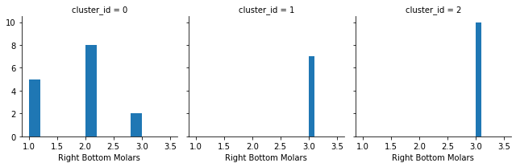

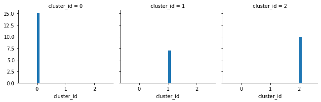

```python
for c in df:
    grid= sns.FacetGrid(df, col='cluster_id')
    grid.map(plt.hist, c)
```

### Inferences Based On Incisors teeth: The incisors are mainly used for cutting the food material.

- Cluster0: Culter0 are those animals who have the average right top incisors of aprroximately 3. Their function is cutting, slicing, or gnawing food into manageable pieces that fit into the mouth for further chewing. So clearly these are the type of 'carnivorous'.
- Both Cluster1 and Cluster2 are having the average right top incisors of aprroximately 1
- So all the types of mammals are having Incisors teeth as for each of them need to cut the food even if it is some plant based food. Just the number of the Incisors teeth differ in them.

### Inferences Based On Premolars teeth: The premolars are used for grinding the food materials.

- Cluster0: Culter0 are those animals who have the maximum no of average premolar teeth aprroximately 3.4 to 3.6(both top and bottom premolars).
- As they eat meat they might need more grinding than other type of mammals. These are used to slice meat and skin. Hence number of grinding teeth is higher in comparison to other 2 clusters. Like - Jaguar
- Cluster1: These are the mammals with the least no of premolars. So these are the animals who need less crushing or grinding in comparison to the other 2 clusters.Like - Rabbit
- Cluster2: These are the mammals with average no of premolars approximately as 2.5 to 2.7. So this is not as low as the cluster1 and also not as high as the cluster0. So these might be those animals who needs less grinding than meat eaters but need crushing because they might eat plant based food like grass. Like - Deer, Elk
- So all the types of mammals are having Premoalrs teeth as for each of them need to grind/crush the food but the only difference is in the number of of theeth in the top and bottom jaws.

### Conclusion based on KMeans using 3 clusters:

- It seems that the cluster0 belongs the carnivorus mammals who eat animal meat mostly.
- It seems that the cluster1 have mammals who eat mostly grass, fruits, seeds, grains like Squirrel, Pike, Rabbit, House Mouse etc. So, we can group them as Herbivores.
- It seems that the cluster2 have both Omnivores like bats and also few Herbivores like Deer as well. Though there are different kinds of bats present who differs in their food habit.
- So now will try to group based on 4 clusters and let's see how well it can divide the groups:
- KMeans using 4 clusters:

```python
#create the instance of the KMeans with optimum no of clusters=3
clusters = KMeans(n_clusters=4)

#fit the scaled data to the model
clusters.fit(scaled_data)

#clusters to which each point has been allocated
clusters.labels_
```

[output not shown]

```python
#store the clusters to the original data
df['cluster_id2'] = clusters.labels_
df.head()
```

|  | mammal | Right Top Incisors | Right Bottom Incisors | Right Top Canines | Right Bottom Canines | Right Top Premolars | Right Bottom Premolars | Right Top Molars | Right Bottom Molars | cluster_id | cluster_id2 |
| --- | --- | --- | --- | --- | --- | --- | --- | --- | --- | --- | --- |
| 0 | Brown Bat | 2 | 3 | 1 | 1 | 3 | 3 | 3 | 3 | 2 | 2 |
| 1 | Mole | 3 | 2 | 1 | 0 | 3 | 3 | 3 | 3 | 2 | 2 |
| 2 | Silver Hair Bat | 2 | 3 | 1 | 1 | 2 | 3 | 3 | 3 | 2 | 2 |
| 3 | Pigmy Bat | 2 | 3 | 1 | 1 | 2 | 2 | 3 | 3 | 2 | 2 |
| 4 | Mouse Bat | 2 | 3 | 1 | 1 | 1 | 2 | 3 | 3 | 2 | 2 |

```python
df['cluster_id2'].value_counts()
```

```
0    15
2    10
1     7
Name: cluster_id2, dtype: int64
```

- So Cluster 4 is not having any animal grouped in the 4th cluster.
- Hence will not consider k value as 4 here

# Hirerarchical Clustring:

- Applying Hirerarchical Clustring on the same dataset considering K=3

```python
#Hirerarchical Clustring

from sklearn.cluster import AgglomerativeClustering
```

```python
from sklearn.metrics import silhouette_score
import scipy.cluster.hierarchy as shc
```

```python
x = df[['Right Top Incisors',
 'Right Bottom Incisors',
 'Right Top Canines',
 'Right Bottom Canines',
 'Right Top Premolars',
 'Right Bottom Premolars',
 'Right Top Molars',
 'Right Bottom Molars']]
```

```python
cluster2 = AgglomerativeClustering(3).fit(x)
cluster2.labels_
```

```
array([0, 0, 0, 0, 0, 0, 2, 2, 2, 2, 2, 2, 2, 1, 1, 1, 1, 1, 1, 1, 1, 1,
       1, 1, 1, 1, 1, 1, 0, 0, 0, 0], dtype=int64)
```

```python
df['cluster_id3'] = cluster2.labels_
```

```python
df[df['cluster_id3']==0]
```

|  | mammal | Right Top Incisors | Right Bottom Incisors | Right Top Canines | Right Bottom Canines | Right Top Premolars | Right Bottom Premolars | Right Top Molars | Right Bottom Molars | cluster_id | cluster_id2 | cluster_id3 |
| --- | --- | --- | --- | --- | --- | --- | --- | --- | --- | --- | --- | --- |
| 0 | Brown Bat | 2 | 3 | 1 | 1 | 3 | 3 | 3 | 3 | 2 | 2 | 0 |
| 1 | Mole | 3 | 2 | 1 | 0 | 3 | 3 | 3 | 3 | 2 | 2 | 0 |
| 2 | Silver Hair Bat | 2 | 3 | 1 | 1 | 2 | 3 | 3 | 3 | 2 | 2 | 0 |
| 3 | Pigmy Bat | 2 | 3 | 1 | 1 | 2 | 2 | 3 | 3 | 2 | 2 | 0 |
| 4 | Mouse Bat | 2 | 3 | 1 | 1 | 1 | 2 | 3 | 3 | 2 | 2 | 0 |
| 5 | Red Bat | 1 | 3 | 1 | 1 | 2 | 2 | 3 | 3 | 2 | 2 | 0 |
| 28 | Reindeer | 0 | 4 | 1 | 0 | 3 | 3 | 3 | 3 | 2 | 2 | 0 |
| 29 | Elk | 0 | 4 | 1 | 0 | 3 | 3 | 3 | 3 | 2 | 2 | 0 |
| 30 | Deer | 0 | 4 | 0 | 0 | 3 | 3 | 3 | 3 | 2 | 2 | 0 |
| 31 | Moose | 0 | 4 | 0 | 0 | 3 | 3 | 3 | 3 | 2 | 2 | 0 |

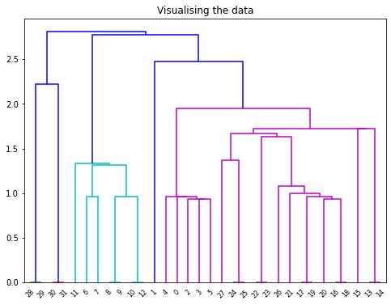

```python
plt.figure(figsize =(8, 6))
plt.title('Visualising the data')
Dendrogram = shc.dendrogram((shc.linkage(scaled_data)))
```

- So from the hierarchical also we are getting 3 clsuters.
- It seems that the 3rd cluster(purple colored) has some kind of overlap as we suspected in the KMeans also.

#### Apply PCA To check if there is any overlap exists or not:

```python
df.columns
```

```
Index(['mammal', 'Right Top Incisors', 'Right Bottom Incisors',
       'Right Top Canines', 'Right Bottom Canines', 'Right Top Premolars',
       'Right Bottom Premolars', 'Right Top Molars', 'Right Bottom Molars',
       'cluster_id', 'cluster_id2', 'cluster_id3'],
      dtype='object')
```

```python
X = df.drop(['mammal','cluster_id', 'cluster_id2', 'cluster_id3'], axis=1)
df1 = pd.DataFrame(data=scaled_data,columns=X.columns)
```

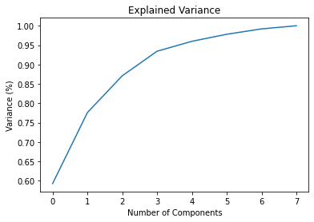

```python
import numpy as np
import matplotlib.pyplot as plt
from sklearn.decomposition import PCA
pca = PCA()
principalComponents = pca.fit_transform(df1)
plt.figure()
plt.plot(np.cumsum(pca.explained_variance_ratio_))
plt.xlabel('Number of Components')
plt.ylabel('Variance (%)') #for each component
plt.title('Explained Variance')
plt.show()
```

```python
pca = PCA(n_components=8)

new_data = pca.fit_transform(df1)

principal_Df = pd.DataFrame(data = new_data
             , columns = ['principal component 1', 'principal component 2','principal component 3','principal component 4','principal component 5','principal component 6','principal component 7','principal component 8'])
```

```python
new_data.shape
```

```
(32, 8)
```

```python
X_clustered = clusters.fit_predict(new_data)
```

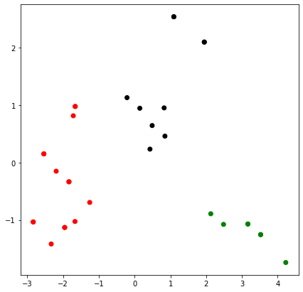

```python
LABEL_COLOR_MAP = {0 : 'red',
                   1 : 'green',
                   2 : 'black'}

label_color = [LABEL_COLOR_MAP[l] for l in X_clustered]
plt.figure(figsize = (7,7))
plt.scatter(new_data[:,0],new_data[:,1], c= label_color, alpha=1)
plt.show()
```